# Plots_and_Analyses.R

```r
# And now export these models.
summ_df %>% write_csv( file = "/labs/jswitte/Projects/jjudd5/SES.PRS_Project/SES_Models/prs_ses_models_2023.11.28.csv")
```

And now plot the SES and PRS OR values

```
[1] "eur"
[1] "afr"
[1] "mix"
[1] "sas"
```

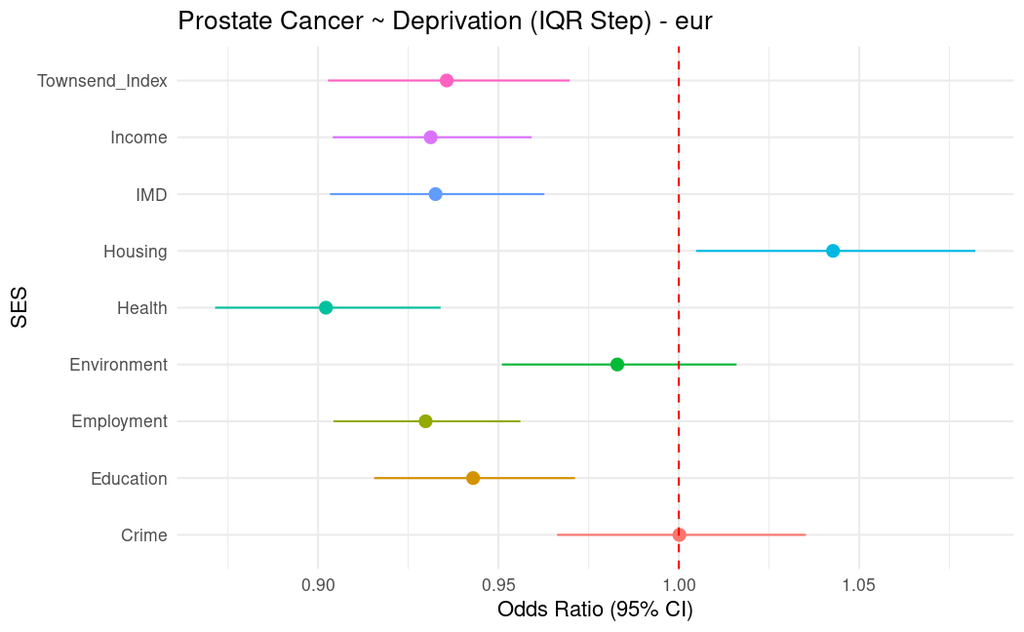

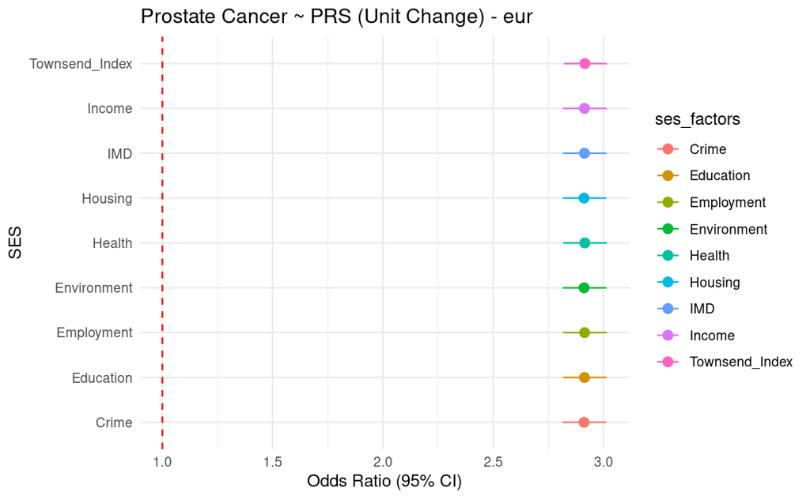

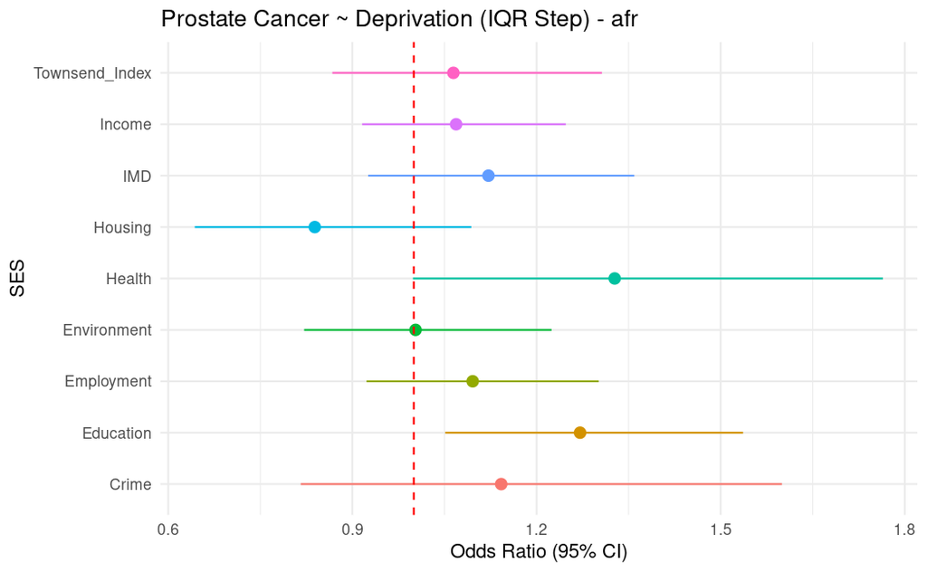

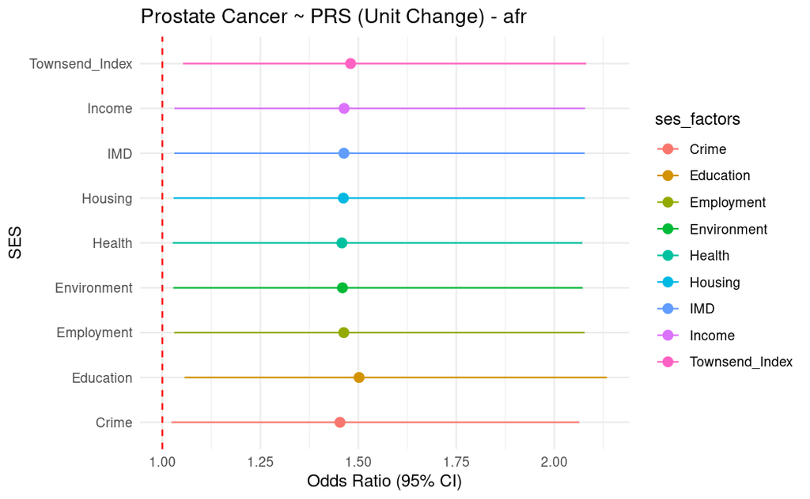

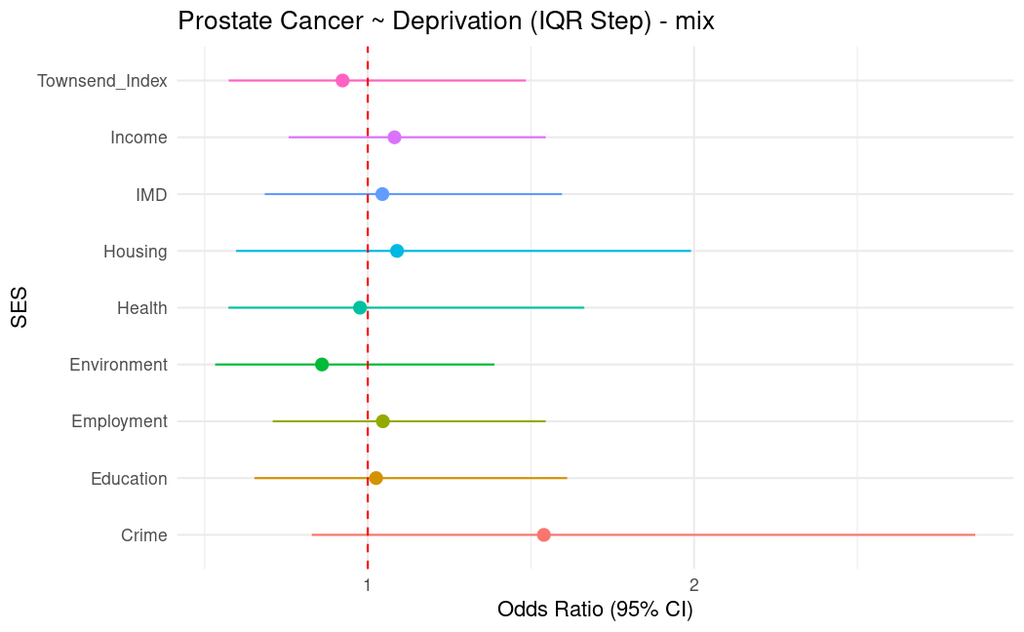

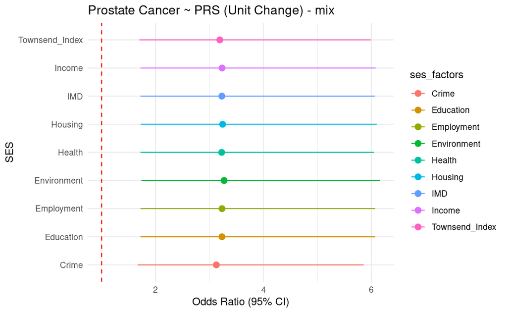

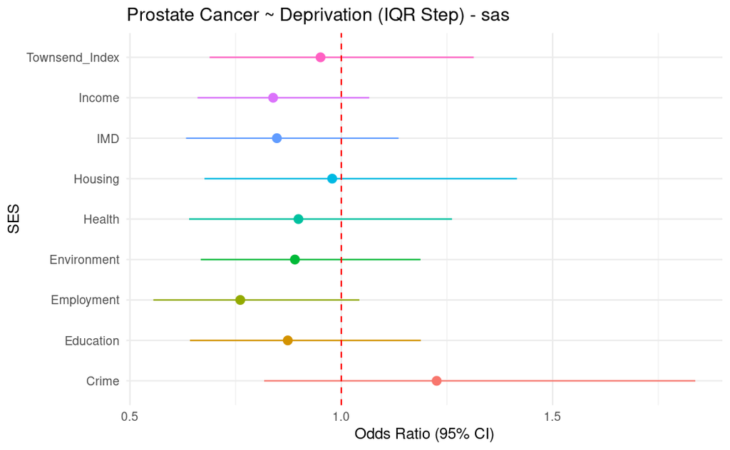

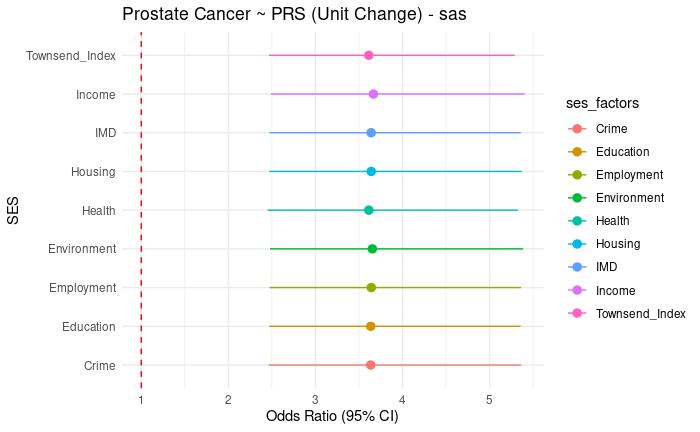

```r
# Edit this df to better plot
`%notin%` = Negate(`%in%`) # Quick helper function

for (j in ances_exclude){

  print(j)

  plotting_df = summ_df %>%
    filter(ancestry == j)

  # Create a plot
  ses_plot = plotting_df %>% filter(str_detect(term, "PRS",negate = T)) %>%
                ggplot(aes(x = OR, y = ses, xmin = low95, xmax = up95, color = ses_factors)
                       ) +
                geom_pointrange(show.legend = FALSE) +
                geom_vline(xintercept = 1, linetype = "dashed", color = "red") +
                labs(x = "Odds Ratio (95% CI)", y = "SES") +
                ggtitle(paste0("Prostate Cancer ~ Deprivation (IQR Step) - ", j)
                        )+
                theme_minimal()

  prs_plot = plotting_df %>% filter(str_detect(term, "PRS"), str_detect(term, ":", negate = T)) %>%
              ggplot(aes(x = OR, y = ses, xmin = low95, xmax = up95, color = ses_factors)) +
              geom_pointrange(show.legend = T) +
              geom_vline(xintercept = 1, linetype = "dashed", color = "red") +
              labs(x = "Odds Ratio (95% CI)", y = "SES") +
              ggtitle(paste0("Prostate Cancer ~ PRS (Unit Change) - ", j)
                      ) +
              theme_minimal()

  print(ses_plot)
  print(prs_plot)

}
```

### Distribution of Data

I need to create a table1. This is basically my understanding the distributions and numbers of my data. I specifically want to know the counts for cases and controls across different groups

```r
# Create a list of variables to save my results
table1 = list()
```

#### SES Distribution

I first want to characterize the distribution of my cases/controls/prevalence across the different nSES/PRS quartiles.

```r
# Remove non-relevant variables
keep_variables = c("data_df", "keep_variables", "ses_factors", "ances",
                   "table1")
rm(list = ls()[!(ls() %in% keep_variables)])


# Create some dataframes to save the prevalence per ancestry
summ_df = tibble()

# I also want to loop through this per ancestry
for (j in ances){

  # I'm basically going to want a lot of data that takes into account the quartile of SES so I'm going to create lasting variables that keep track of that
  data_split = data_df %>% filter(Ances == j)

  for (i in ses_factors){

  # Make symbol for coding sake
    sym_i = sym(i)

    data_split = data_split %>% drop_na( !!sym_i ) %>%
      mutate(temp = ntile(!!sym_i,4)) %>%
      rename_with( ~ paste0(i, "_quartile"), matches("temp"))
  }

  data_split = data_split %>% drop_na(PRS) %>%
    mutate(PRS_quartile = ntile(PRS,4))


  # I can now basically use this split dataset to pull things like the case/controls (and thus prevalence for the different groups that I care about)
  # Let's start by pulling the nSES variables, their quartiles, and the case/controls. I also need this data longer
    split_prev = data_split %>%
      select(contains( c("eid",
                         "quartile",
                         "prostate_incident"))
             ) %>%
      pivot_longer(cols = contains("quartile"),names_to = "Domain", values_to = "Quartile")


  # I will now summarize this data to categorize case/controls as well as prevalence at the end
  prev_summary =  split_prev %>%
    group_by(Domain, Quartile, prostate_incident) %>%
    summarize(Count = n()) %>%
    na.omit() %>%
    pivot_wider(names_from = prostate_incident, values_from = Count) %>%
    rename(Controls = "0", Cases = "1") %>%
    mutate(Prevalence = round(Cases/Controls,2)
           )


  # Add the ancestry and save to overarching dataframe
  summ_df = prev_summary %>%
    mutate(ancestry = j) %>%
    rbind(summ_df, .)

}

# Save the summary variables
table1 = table1 %>% list_assign(nSES_dist = summ_df
                                )
```

#### PSA Distribution

I’m also interested in the split of PSA screening for different SES groups for both cases and controls. I may not end up splitting the data by SES in the end, but that can be a later transofrmation

I largely just want the case/controls split for never/ever screened. I have code for quartile never/ever screened as well as screened in controls/cases over ses quartiles in previous iterations. I can redo that for a suppliment, but don’t need it here.

```r
# Remove non-relevant variables
keep_variables = c("data_df", "keep_variables", "ses_factors", "ances",
                   "table1")
rm(list = ls()[!(ls() %in% keep_variables)])


# Create some dataframes to save the prevalence per ancestry
summ_df = tibble()

# I also want to loop through this per ancestry
for (j in ances){

  # I'm basically going to want a lot of data that takes into account the quartile of SES so I'm going to create lasting variables that keep track of that
  data_split = data_df %>% filter(Ances == j)

  # I can now use this to pull the main columns of interest
  split_psa = data_split %>%
    select(contains( c("eid",
                       "prostate_incident",
                       "PSA_Screening"))
           ) %>% na.omit() %>%
    # Now group by my 2 variables and see where they land
    group_by(prostate_incident, PSA_Screening) %>%
    summarize(Count = n()) %>%
    # Pivot-wider for understanding sake
    pivot_wider(names_from = prostate_incident, values_from = Count) %>%
    rename(Controls = "0", Cases = "1")

    # Add the ancestry and save to overarching dataframe
  summ_df = split_psa %>%
    mutate(ancestry = j) %>%
    rbind(summ_df, .)


}
# Now I can save this
table1 = table1 %>% list_assign(psa_dist = summ_df
                                )
```

#### Anthropomorphic Distribution

There it is. I’ve calculated the numbers per SES variable. Now I want to do the same for other variables, such as age, height, and BMI

```r
# Remove non-relevant variables
keep_variables = c("data_df", "keep_variables", "ses_factors", "ances",
                   "table1")
rm(list = ls()[!(ls() %in% keep_variables)])

# Pull out the age, height, and BMI data
data_split = data_df %>%
  select(contains(c("eid", "Ances",
                    "prostate_incident",
                    "age_assessment",
                    "height",
                    "BMI")),
         )

# I will now summarize this data to categorize case/controls as well as prevalence at the end
describe_summ =  data_split %>%
  na.omit() %>%
  group_by(prostate_incident, Ances) %>%
  summarize(age_mean = mean(age_assessment),
            age_sd = sd(age_assessment),
            height_mean = mean(Height),
            height_sd = sd(Height),
            bmi_mean = mean(BMI),
            bmi_sd = sd(BMI))
# Save the summary variables
table1 = table1 %>% list_assign(gen_dist = describe_summ
                                )
```

### Extra Analyses

This is a place for extra analyses that I don’t think I would need to edit repetitively, but still need to be in this document since it incorporates the 451 variant PRS and my different ancestries

#### Interaction Co-linearity

I’m curious if my interaction models are wonky because the main effect and the interaction effect have very high correlation and thus cause co-linearity.

| term | PRS | IMD | Income | Employment | Health | Education | Housing | Crime | Environment | Townsend_Index | IMD*PRS | Income*PRS | Employment*PRS | Health*PRS | Education*PRS | Housing*PRS | Crime*PRS | Environment*PRS | Townsend_Index*PRS |
| --- | --- | --- | --- | --- | --- | --- | --- | --- | --- | --- | --- | --- | --- | --- | --- | --- | --- | --- | --- |
| PRS | NA | -0.10444015 | -0.126997141 | -0.05567387 | -0.04611124 | -0.04117631 | -0.10646632 | -0.09004895 | -0.1261422 | -0.1361770 | -0.03241020 | -0.054791553 | 0.01762278 | -0.04241568 | 0.007895715 | -0.004247582 | -0.07833584 | -0.05280862 | -0.1330915 |
| IMD | -0.104440148 | NA | 0.961910094 | 0.93164702 | 0.82202888 | 0.84756483 | 0.06778323 | 0.62537631 | 0.5805381 | 0.7305607 | 0.99612280 | 0.960691057 | 0.92331319 | 0.81946170 | 0.841786199 | 0.054956369 | 0.62284415 | 0.57508964 | 0.7293231 |
| Income | -0.126997141 | 0.96191009 | NA | 0.90895049 | 0.76530979 | 0.81759089 | 0.02561600 | 0.53789827 | 0.5073921 | 0.7249555 | 0.95500172 | 0.995866438 | 0.89811423 | 0.76216181 | 0.810128173 | 0.009307848 | 0.53471994 | 0.49882091 | 0.7224965 |
| Employment | -0.055673871 | 0.93164702 | 0.908950488 | NA | 0.83820973 | 0.80244212 | -0.11952728 | 0.46638153 | 0.3857428 | 0.6240471 | 0.93208672 | 0.912277646 | 0.99622168 | 0.83673674 | 0.799777707 | -0.128008304 | 0.46503117 | 0.38318876 | 0.6239032 |
| Health | -0.046111235 | 0.82202888 | 0.765309785 | 0.83820973 | NA | 0.67632505 | -0.13782717 | 0.46167659 | 0.3912610 | 0.5682086 | 0.82294145 | 0.768524480 | 0.83549702 | 0.99904017 | 0.674152549 | -0.145148907 | 0.46054532 | 0.38970955 | 0.5682550 |
| Education | -0.041176309 | 0.84756483 | 0.817590888 | 0.80244212 | 0.67632505 | NA | -0.11675750 | 0.48344560 | 0.3195740 | 0.5451365 | 0.84935395 | 0.822101749 | 0.80017506 | 0.67527723 | 0.997745240 | -0.122157902 | 0.48286432 | 0.31814444 | 0.5460530 |
| Housing | -0.106466324 | 0.06778323 | 0.025616004 | -0.11952728 | -0.13782717 | -0.11675750 | NA | 0.02514803 | 0.2074613 | 0.1504553 | 0.05811261 | 0.014743335 | -0.12939477 | -0.13969312 | -0.122409748 | 0.993668849 | 0.02219831 | 0.19957741 | 0.1471749 |
| Crime | -0.090048950 | 0.62537631 | 0.537898270 | 0.46638153 | 0.46167659 | 0.48344560 | 0.02514803 | NA | 0.5155880 | 0.4861894 | 0.62272740 | 0.536393037 | 0.46038392 | 0.46097447 | 0.479838130 | 0.014340441 | 0.99908071 | 0.51329742 | 0.4865570 |
| Environment | -0.126142177 | 0.58053814 | 0.507392141 | 0.38574284 | 0.39126100 | 0.31957403 | 0.20746127 | 0.51558801 | NA | 0.5777525 | 0.57217027 | 0.499842100 | 0.37498284 | 0.38863029 | 0.312161896 | 0.193728188 | 0.51284566 | 0.99594130 | 0.5757651 |
| Townsend_Index | -0.136177033 | 0.73056069 | 0.724955485 | 0.62404709 | 0.56820864 | 0.54513653 | 0.15045531 | 0.48618937 | 0.5777525 | NA | 0.72268005 | 0.718863576 | 0.61320963 | 0.56572491 | 0.538235034 | 0.133884710 | 0.48306811 | 0.56980970 | 0.9986561 |

[output cut: 9 more lines]

#### Binary SES*PRS Models

My current interaction models are possibly inaccurate due to small samples sizes and co-linearity. To understand the interaction between my SES and PRS terms, I am going to make all my indices and PRS as a 0/1 binary variable.

The interaction term will now represent high deprivation and high PRS to be more interpretable

```r
keep_variables = c("data_df", "keep_variables", "ses_factors",
                   "ances","ances_exclude")
rm(list = ls()[!(ls() %in% keep_variables)])



# Create some dataframes to save the prevalence per ancestry
summ_df = tibble()

# I also want to loop through this per ancestry
for (j in ances_exclude){

  # Print ancestry to benchmark
  print(j)

  # Let's pull out the ancestry specific data and set list for models for this ancestry
  data_split = data_df %>% filter(Ances == j)
  model_results = list()

  # Now create a loop that models the variables of interest and then saves them to a list of models
  # Each loop will run a model for total, incidence, and prevalent cases
  for (i in ses_factors){

    # Make symbol for coding sake
      i = sym(i)

    # Create new data frame with binary data for each of the SES factors and for PRS
      temp_df = data_split %>% drop_na( !!i ) %>%
        mutate(High_Deprivation = as.factor( ntile(!!i,2) - 1 )
               ) %>%
        mutate(High_PRS = as.factor( ntile(PRS,2) - 1 )
               )

      # Run models of interest
      formula = paste0("prostate_case ~ High_Deprivation + High_PRS + High_Deprivation*High_PRS",
                       " + age_assessment + PSA_Screening", str_flatten(str_c("+ PC",1:10))
                       ) %>% as.formula()

      model = logistic_reg() %>% fit(formula, data = temp_df)

      # Tidy the data from the model
      OR = tidy(model, exponentiate = T) %>%
        rename(OR = estimate) %>%
        mutate(low95 = exp(log(OR) - 1.96*std.error),
               up95 = exp(log(OR) + 1.96*std.error)) %>%
        select(-std.error, -statistic) %>%
        .[-c(1,4:15),]


      # Keep only relevant results before saving it in the model
      model_results[[i]] <- OR


    # Benchmark that this set of model is complete
    print(i)
  }


  # Save the models
  results_df = list_rbind(model_results, names_to = "ses")

    # Then add to summary data_frame
    summ_df = results_df %>%
      mutate(ancestry = j) %>%
      rbind(summ_df, .)

}
```

```
[1] "eur"
IMD
Income
Employment
Health
Education
Housing
Crime
Environment
Townsend_Index
[1] "afr"
IMD
Income
Employment
Health
Education
Housing
Crime
Environment
Townsend_Index
[1] "mix"
IMD
Income
Employment
Health
Education
Housing
Crime
Environment
Townsend_Index
[1] "sas"
IMD
Income
Employment
Health
Education
Housing
Crime
Environment
Townsend_Index
```

```r
# And now export these models.
summ_df %>%
  write_csv( file = "/labs/jswitte/Projects/jjudd5/SES.PRS_Project/SES_Models/binary_ses_models_2023.12.01.csv")
```

I want to plot these results and also make a 2*2 table for each of the high deprivation or PRS groups

```
[1] "eur"
[1] "afr"
[1] "mix"
[1] "sas"
```

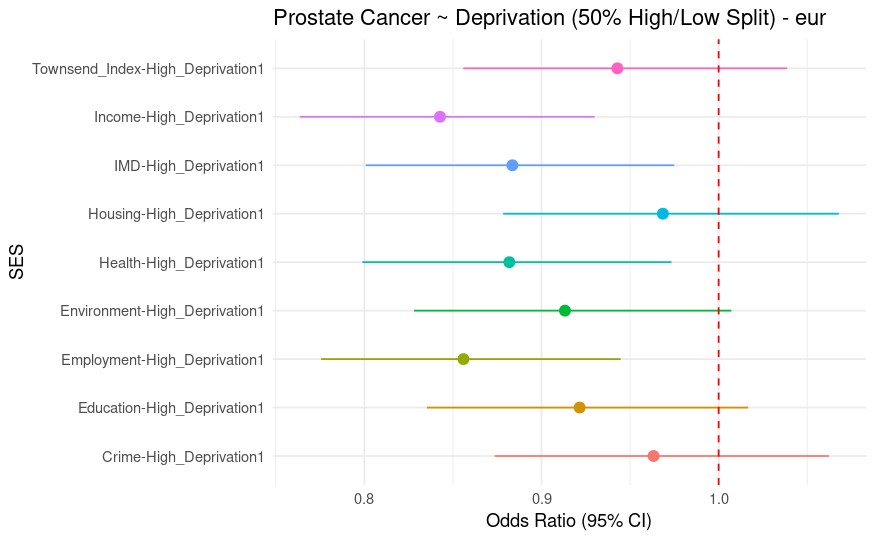

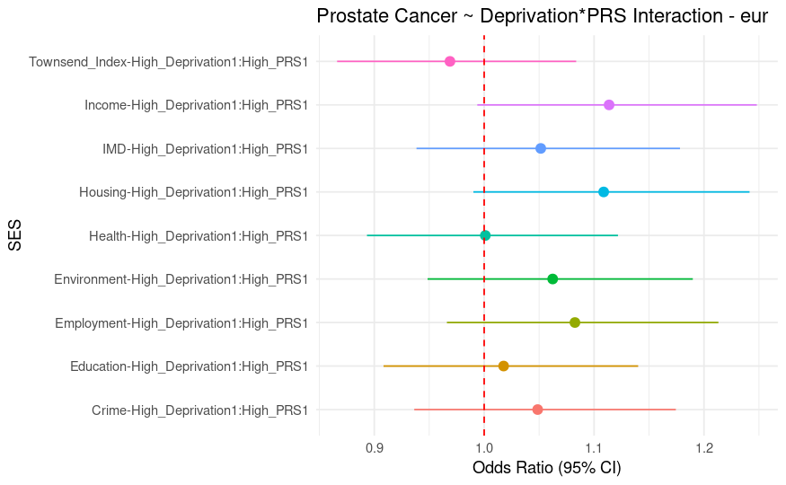

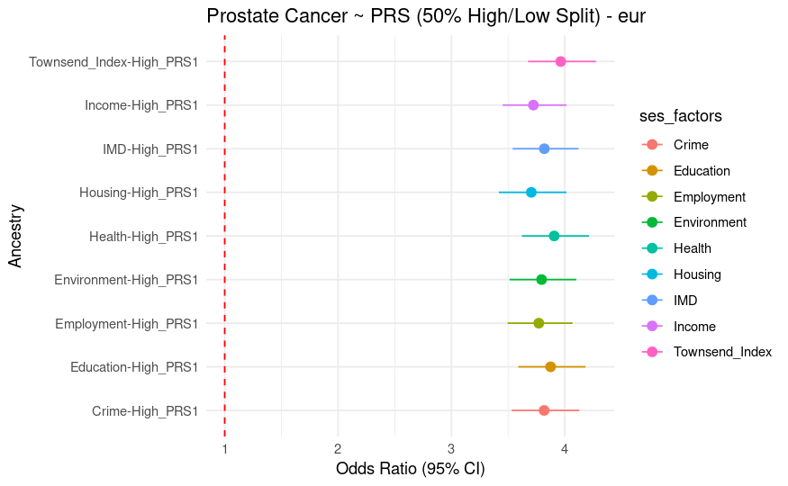

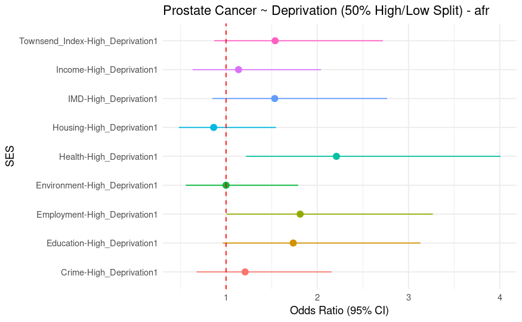

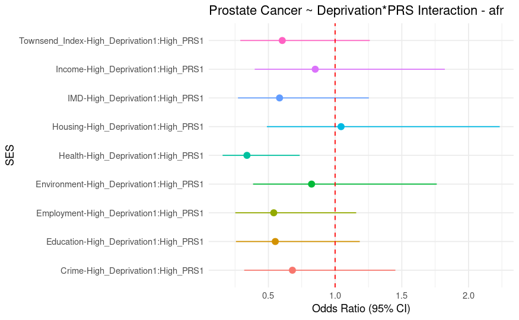

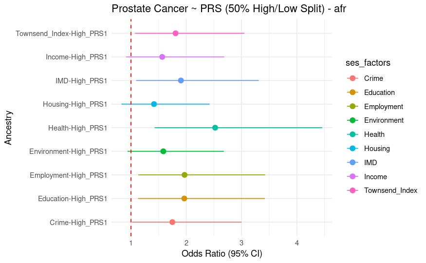

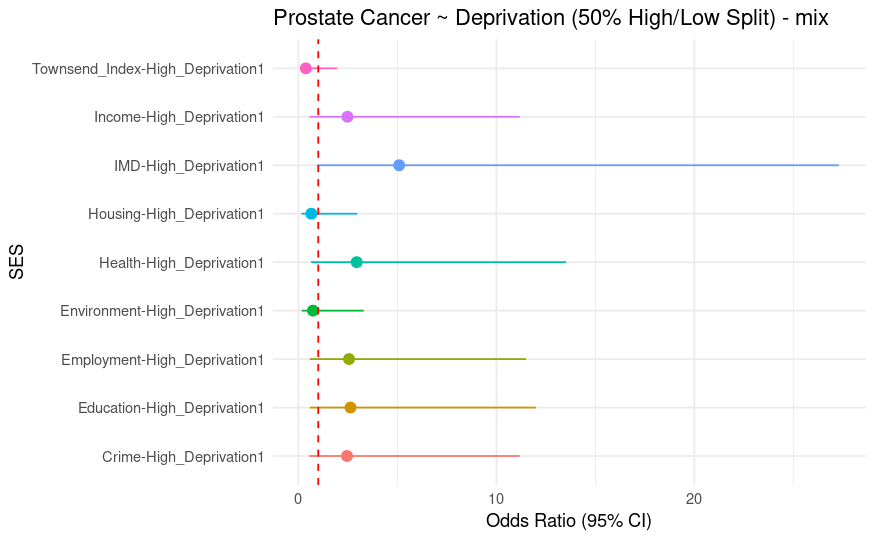

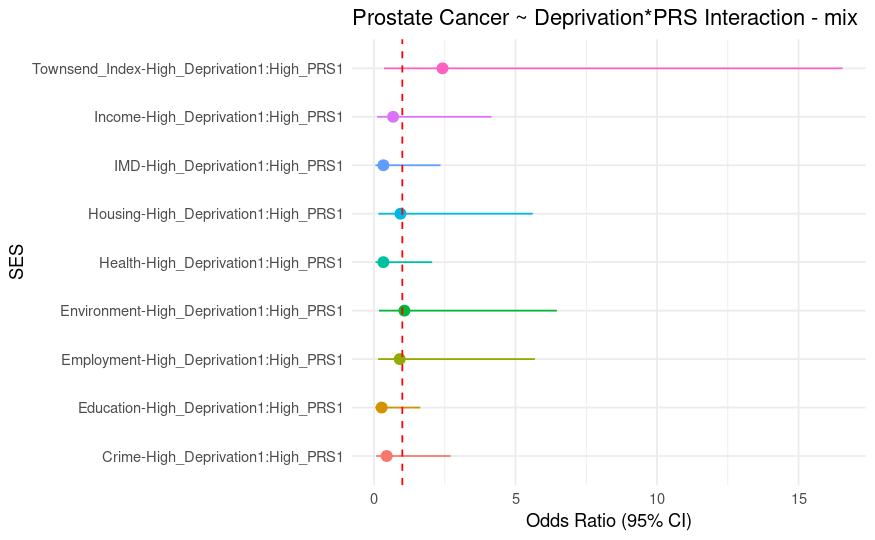

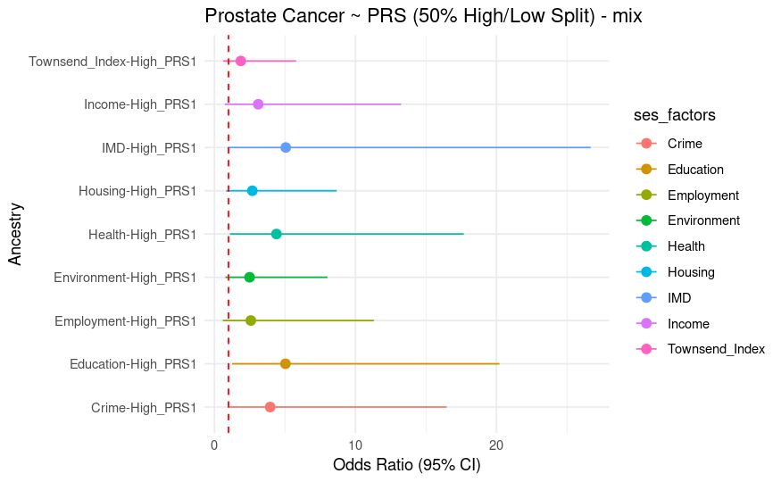

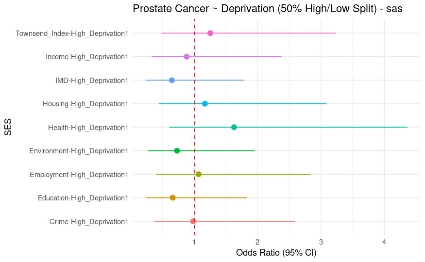

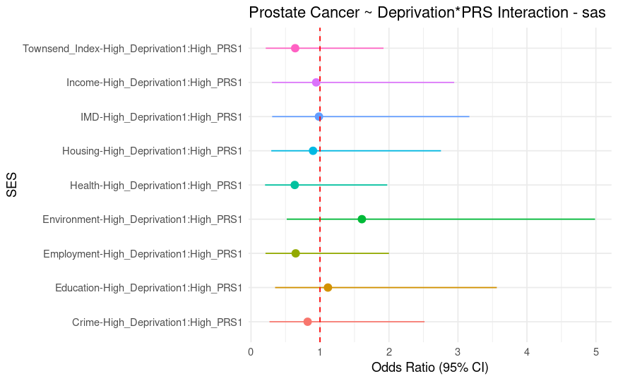

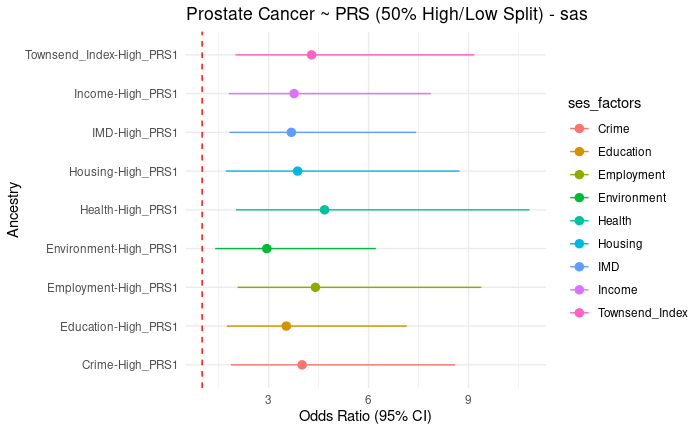

```r
# Edit this df to better plot
`%notin%` = Negate(`%in%`) # Quick helper function

for (j in ances_exclude){

  print(j)

  plotting_df = summ_df %>%
    filter(ancestry == j) %>%
    mutate(SES_Binary = as.factor(paste0(ses, "-",term)))


  # Create a plot
  ses_plot = plotting_df %>% filter(str_detect(term, "PRS",negate = T)) %>%
                ggplot(aes(x = OR, y = SES_Binary, xmin = low95, xmax = up95, color = ses_factors)
                       ) +
                geom_pointrange(show.legend = FALSE) +
                geom_vline(xintercept = 1, linetype = "dashed", color = "red") +
                labs(x = "Odds Ratio (95% CI)", y = "SES") +
                ggtitle(paste0("Prostate Cancer ~ Deprivation (50% High/Low Split) - ", j)
                        )+
                theme_minimal()

  int_plot = plotting_df %>% filter(str_detect(term, ":")) %>%
                ggplot(aes(x = OR, y = SES_Binary, xmin = low95, xmax = up95, color = ses_factors)
                       ) +
                geom_pointrange(show.legend = FALSE) +
                geom_vline(xintercept = 1, linetype = "dashed", color = "red") +
                labs(x = "Odds Ratio (95% CI)", y = "SES") +
                ggtitle(paste0("Prostate Cancer ~ Deprivation*PRS Interaction - ", j)
                        )+
                theme_minimal()

  prs_plot = plotting_df %>% filter(str_detect(term, "PRS"), str_detect(term, ":", negate = T)) %>%
              ggplot(aes(x = OR, y = SES_Binary, xmin = low95, xmax = up95, color = ses_factors)) +
              geom_pointrange(show.legend = T) +
              geom_vline(xintercept = 1, linetype = "dashed", color = "red") +
              labs(x = "Odds Ratio (95% CI)", y = "Ancestry") +
              ggtitle(paste0("Prostate Cancer ~ PRS (50% High/Low Split) - ", j)
                      ) +
              theme_minimal()

  print(ses_plot)
  print(int_plot)
  print(prs_plot)

}
```

#### Standardize SES*PRS Models

While I plan to standardize all my models in the future, my main concern is to standardize the SES and PRS values for the interaction model. Once I do this and have an expectation for the result, I will standardize my variables for future models.

```r
keep_variables = c("data_df", "keep_variables", "ses_factors",
                   "ances","ances_exclude")
rm(list = ls()[!(ls() %in% keep_variables)])



# Create some dataframes to save the prevalence per ancestry
summ_df = tibble()

# I also want to loop through this per ancestry
for (j in ances_exclude){

  # Print ancestry to benchmark
  print(j)

  # Let's pull out the ancestry specific data and set list for models for this ancestry
  data_split = data_df %>% filter(Ances == j)
  model_results = list()

  # Now create a loop that models the variables of interest and then saves them to a list of models
  # Each loop will run a model for total, incidence, and prevalent cases
  for (i in ses_factors){


    # Create symbol for coding reason
    i = sym(i)

    # Calculate the standardized data for the Deprivation index of interest
      temp_df = data_split %>% drop_na(!!i) %>%
        mutate(Deprivation_z = scale(!!i)[,1]
               )

    # Run models of interest
      formula = paste0("prostate_case ~ Deprivation_z + PRS_z + Deprivation_z*PRS_z",
                       " + age_assessment + PSA_Screening", str_flatten(str_c("+ PC",1:10))
                       ) %>% as.formula()

      model = logistic_reg() %>% fit(formula, data = temp_df)

      OR = tidy(model, exponentiate = T) %>%
        rename(OR = estimate) %>%
        mutate(low95 = exp(log(OR) - 1.96*std.error),
               up95 = exp(log(OR) + 1.96*std.error)) %>%
        select(-std.error, -statistic)

      # Pull specific results before saving
      model_results[[i]] <- OR[c(2,3,16),]


    # Benchmark that this set of model is complete
    print(i)
  }


  # Save the models
  results_df = list_rbind(model_results, names_to = "ses")

    # Then add to summary data_frame
    summ_df = results_df %>%
      mutate(ancestry = j) %>%
      rbind(summ_df, .)

}
```

```
[1] "eur"
IMD
Income
Employment
Health
Education
Housing
Crime
Environment
Townsend_Index
[1] "afr"
IMD
Income
Employment
Health
Education
Housing
Crime
Environment
Townsend_Index
[1] "mix"
IMD
Income
Employment
Health
Education
Housing
Crime
Environment
Townsend_Index
[1] "sas"
IMD
Income
Employment
Health
Education
Housing
Crime
Environment
Townsend_Index
```

```r
# And now export these models.
summ_df %>%
  write_csv( file = "/labs/jswitte/Projects/jjudd5/SES.PRS_Project/SES_Models/interaction_standardized_models_2023.12.12.csv")
```

Now the plotting

```
[1] "eur"
[1] "afr"
[1] "mix"
[1] "sas"
```

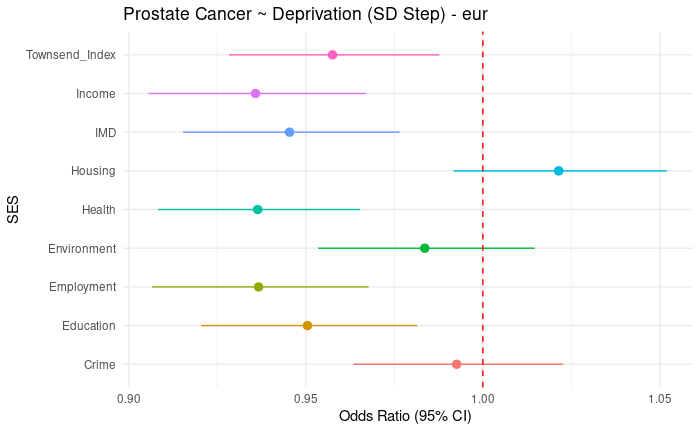

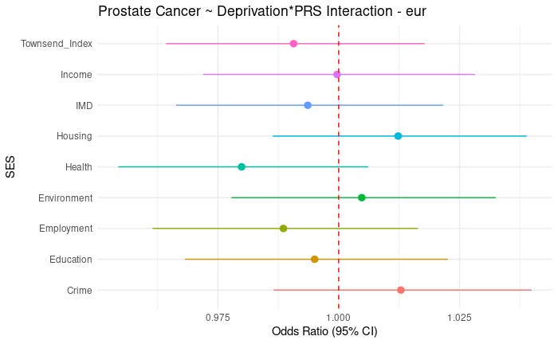

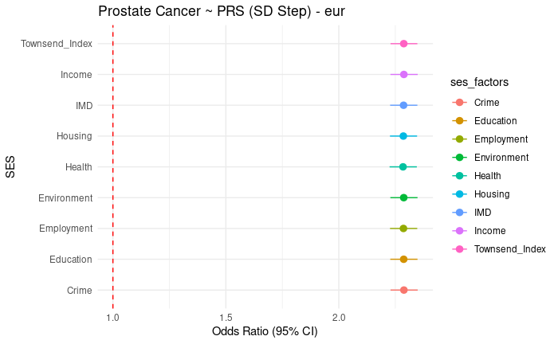

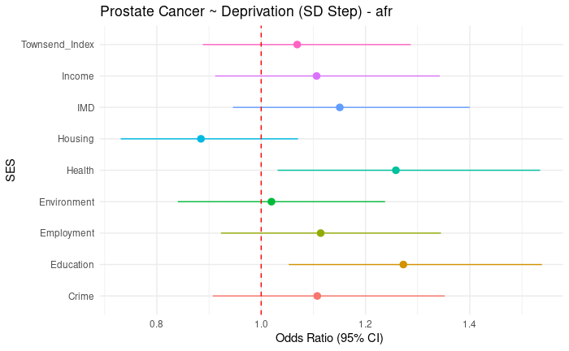

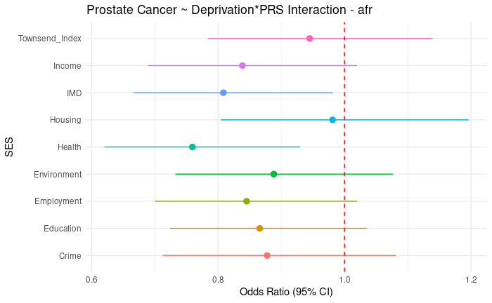

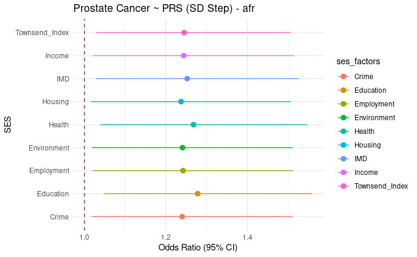

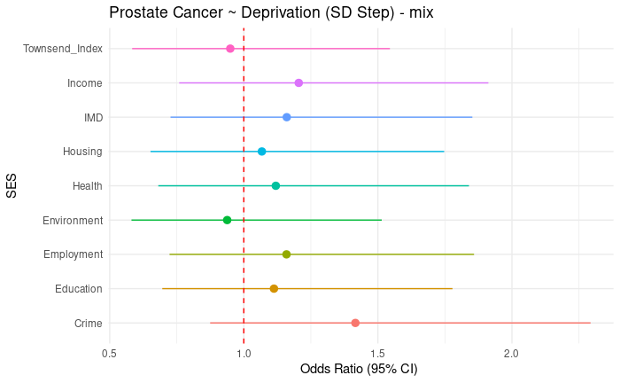

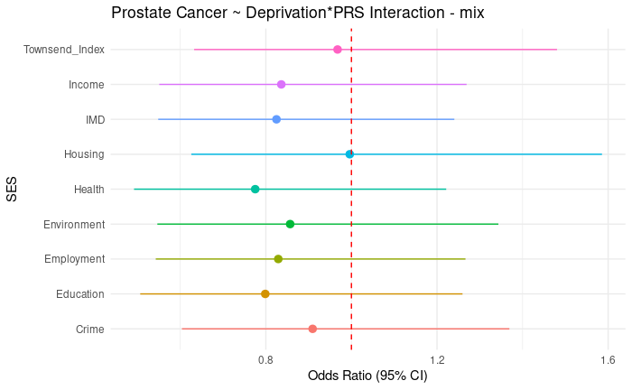

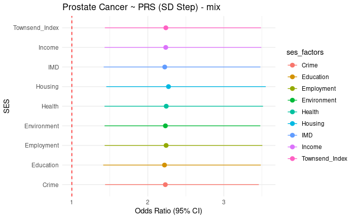

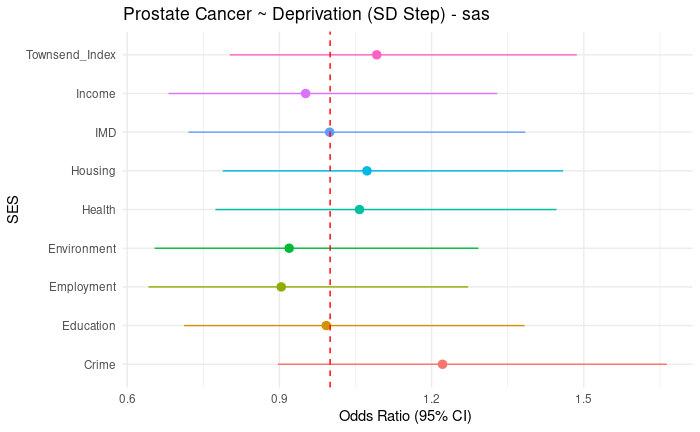

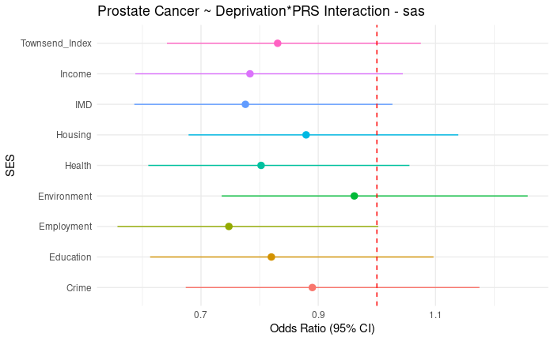

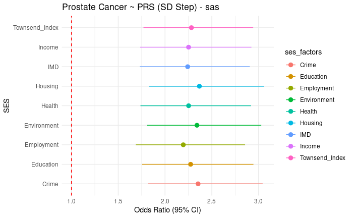

```r
# Edit this df to better plot
`%notin%` = Negate(`%in%`) # Quick helper function

for (j in ances_exclude){

  print(j)

  plotting_df = summ_df %>%
    filter(ancestry == j)

  # Create a plot
  ses_plot = plotting_df %>% filter(str_detect(term, "PRS_z",negate = T)) %>%
                ggplot(aes(x = OR, y = ses, xmin = low95, xmax = up95, color = ses_factors)
                       ) +
                geom_pointrange(show.legend = FALSE) +
                geom_vline(xintercept = 1, linetype = "dashed", color = "red") +
                labs(x = "Odds Ratio (95% CI) ", y = "SES") +
                ggtitle(paste0("Prostate Cancer ~ Deprivation (SD Step) - ", j)
                        )+
                theme_minimal()

  int_plot = plotting_df %>% filter(str_detect(term, ":")) %>%
                ggplot(aes(x = OR, y = ses, xmin = low95, xmax = up95, color = ses_factors)
                       ) +
                geom_pointrange(show.legend = FALSE) +
                geom_vline(xintercept = 1, linetype = "dashed", color = "red") +
                labs(x = "Odds Ratio (95% CI)", y = "SES") +
                ggtitle(paste0("Prostate Cancer ~ Deprivation*PRS Interaction - ", j)
                        )+
                theme_minimal()

  prs_plot = plotting_df %>% filter(str_detect(term, "PRS_z"), str_detect(term, ":", negate = T)) %>%
              ggplot(aes(x = OR, y = ses, xmin = low95, xmax = up95, color = ses_factors)) +
              geom_pointrange(show.legend = T) +
              geom_vline(xintercept = 1, linetype = "dashed", color = "red") +
              labs(x = "Odds Ratio (95% CI)", y = "SES") +
              ggtitle(paste0("Prostate Cancer ~ PRS (SD Step) - ", j)
                      ) +
              theme_minimal()

  print(ses_plot)
  print(int_plot)
  print(prs_plot)

}
```